# Appelbaum-AftermathOfDownsizing-1998-JMD.pdf

Converted from PDF `Appelbaum-AftermathOfDownsizing-1998-JMD.pdf` · 30 pages · anchors: page `#pN`, block `#pN-bK`

Page 1

Journal of Management Development 17,6

#### **402**

## **The aftermath of downsizing**

### **A case study of disengagement, disidentification, disenfranchisement**

### **and disenchantment**

### Steven H. Appelbaum *Concordia University, Montreal, Canada*

### Manon Leblanc *Air Canada Vacations, Montreal, Canada, and*

### Barbara T. Shapiro *Concordia University, Montreal, Canada*

**Introduction and background** Dominion Travelogics Unlimited (DTU) is a company that recently survived a major corporate reorganization. DTU is a wholesale tour operator. Its primary business is the packaging and selling of vacation tours through travel agencies. The company was created about 25 years ago to increase package tour sales in the leisure market. With offices located in six major Canadian cities DTU employs approximately 200 people nationwide. In the past, DTU had total freedom of deciding on the products it wanted to offer and had the liberty of choosing its own suppliers. DTU’s mission was focused on profitability which was clearly reflected in corporate policies.

In the early 1990s, DTU started losing money due to the opening of too many branch offices too quickly and because some airlines decided to forego previously popular markets. As a result of this, in 1993, DTU redefined its mission. The new mandate was to increase its profitability selling allocated leisure capacity (a pre-determined number of seats for tour packages provided by carriers on certain flights) and vacation experiences that satisfy typical clientele. The new mission affected DTU in many ways, but primarily there was less product that was available for sale. The new mission led to less revenue for the company. Therefore, fewer employees were needed resulting in multi-level layoffs (i.e. reservation agents, ticketing agents, staff in inventory control, accounts receivable, payables, destination services and customer services).

Downsizing had detrimental effects on the employees as indicated by the attitude (climate) survey (Appendix). After examining the restructuring process chosen by the company, the main problem appeared to involve cultural issues, which were aggravated by a lack of leadership and poor communication. It is important to note that over 50 per cent of employees are female, the average age is 32 years, and 75 per cent work in technical support positions.

Journal of Management Development, Vol. 17 No. 6, 1998, pp. 402-431, © MCB University Press, 0262-1711

Page 2

#### The aftermath

#### of downsizing

#### **403**

Although the numbers of employees has recently been reduced from approximately 350 to 200, the result is a very tightly knit group and a powerful grapevine. DTU operates in a very competitive environment, where commercial issues must be kept confidential. Communication problems often arise because some confidential information is shared beyond the managers and some routine directives fail to reach the office staff.

DTU employees shared the values and norms that they had helped to define. After the reorganization, not only did the employees feel a loss of freedom, the policies and the rules of the game were being redefined. Major budget cuts resulted in cancellation of social events and employee recognition programs which led to a significant drop in motivation. Salaries have been frozen for three years resulting in hiring not being permitted even to replace employees who have left. As a result, many departments have seen their job load increase but no compensation has been offered.

The restructuring process chosen by the company appears to be related to the cultural problem. Small groups of employees were being laid-off on Friday afternoons without warning. The loss of valuable co-workers who were also close friends could be compared to the death of a loved one. There was a sense of loss and a feeling of insecurity among the survivors about their own jobs. It was rumored that if the financial position of the company did not improve, additional layoffs would be announced.

In the past ten years, DTU has had five presidents, each of them originating from very different disciplines. They arrived at DTU with their own vision, strategies, and ways of thinking and working. They all had a two-year mandate during which employees had to adapt to the newly imposed culture. Although there was never any real continuation from one CEO’s view to the next, the employees always seemed to slowly adapt to the new views. The changes being implemented were mostly organizational changes that only had an indirect effect on DTU employees. The most recent change included major staff downsizing and this time the remaining employees have not been able to adapt well at all.

**What is the problem?** Individuals vary widely in their openness to and enthusiasm for change (Carr, 1994, p. 55). It is inevitable that people are going to feel anxiety and stress after downsizing. Many researchers of organizational change have observed from their surveys that organizational productivity deteriorates after downsizing. The employees who remain after downsizing are referred to as the “survivors.” The symptoms of an unproductive survivor culture have been described by human resource professionals as a lack of motivation, loyalty, trust and recommitment to the new organization. Feelings of being deceived, anger and frustration all contribute to the low employee morale and lost productivity (Cameron, 1994, p. 190; Markowitch, 1994, p. 70). One of the most common reasons why companies that downsize perform so poorly is that they often are successful at anticipating and preparing for the employees who are released,

Page 3

Journal of Management Development 17,6

#### **404**

but they may not be prepared for the low morale and lower productivity experienced by the survivors of the downsizing (Isabella, 1989, p. 35).

The central problem for DTU is to initiate a process that will promote development of a new corporate culture which is congruent with the needs of the company as a business entity and the needs of employees. The relevant issues are:

• examine the current culture to discover specific problem areas; • select techniques appropriate to DTU for addressing the cultural problem; • make recommendations concerning the techniques including a suggested timeframe for action and need for feedback measures; • that management is committed to accepting feedback with a view to acting on recommendations which have a sound basis in research and historical practice regarding downsized companies; • that employees and management understand human resources are a company’s most significant asset.

**Organizational climate** The questionnaire which was developed for this study and which will be further described next in the methodology section of this article was intended to describe the attitudes or climate of DTU employees. Determining the organizational climate within an organization is a different and complex task for a consultant, human resource specialist or administrator. Each organization has a personality of its own, and this dynamic variable is its organization climate. Personality is to the individual what organizational climate is to the organization.

Once the dimensions of an organization climate are determined, a strategy can be developed to enable a manager to intervene and change that climate. The strategy might include these steps:

(1) *Diagnosis.* The process in which the need for change is examined. (2) *Strategy planning*. Determines methods to be employed such as surveys,

interviews, team building, etc. (3) *Education*. Required to unfreeze old patterns and incorporate new

information into the organization. (4) *Intervention and analysis*. The process of interaction between consultant

and manager in order to yield data and analysis. (5) *Feedback*. The essence of the organizational climate study. It involves

discussion of the data by the department under study. (6) *Facilitation*. The means of assisting the department manager in

implementing changes in climate.

Page 4

#### The aftermath

#### of downsizing

#### **405**

(7) *Evaluation.* A process of continuous appraisal of the effects of planned

change in terms of personal need fulfillment and organizational effectiveness (Appelbaum, 1976, p. 12). Organizational climate is the pattern, style and feeling characteristic of interpersonal relationships among members of an organization and also characteristic of the relations between members of the organization and people outside of the organization. It may be assessed by observing many aspects of the relationship in many different situations. Organizational climate is a relatively enduring quality of the internal environment of an organization that:

• is experienced by its members; • influences their behavior; and • can be described in terms of the values of a particular set of characteristics (or attributes) of the organization (Litwin and Taguiri, 1968). The climate can shape or modify the behavior of individuals in groups that become new members of the organization as well as being the guideline for the relationships among organization members of longer seniority. Causal relationships among climate variables and also outcomes may not be unidirectional; for example, the innovative adoption of new practices by an organization may change the climate in the organization as well as the consequence of the climate. Individual perceptions of the variances within the organizational climate when combined are relatively stable over time and are often closely related to outcomes of technical importance (Appelbaum, 1984, p. 52).

To study a climate, surveys consisting of interviews or questionnaires have enjoyed wide-spread use in organizations as sources of information on functioning. It is a rare employee who has not responded to at least one survey of his or her morale, feelings, attitudes, beliefs, or opinions. The rationale for conducting organizational surveys – whether conducted by outside consultants or in-house staff such as human resource specialists – is to assemble information that will aid management in diagnosing problems and selecting remedies. Top management occasionally feels that it has done the right thing just by authorizing a survey. It is assumed that workers will feel much better after having “blown off steam” and gotten the impression that management is interested in them. This is not always the case.

A survey’s immediate effect may be somewhat positive; respondents sometimes experience mild catharsis in expressing their attitudes and feelings. But in responding, employees may be led to expect that survey information, including their own statements, will be used to rectify the problems and unpleasant situation being described. These employees may become cynical, if not angry, about management’s motives in instigating the survey. One can make a strong case that it is better to let sleeping dogs lie and not conduct a survey

Page 5

Journal of Management Development 17,6

#### **406**

than it is to raise expectations inadvertently and leave them unfulfilled (Appelbaum, 1984, p. 55).

If survey results are to be used effectively, managers must understand the results and their implications, and incorporate this information with existing attitudes and behavior. Participation must begin at the outset of the project with the support of the top executive. In addition, at the conclusion of the survey, participation continues via the feedback process involving all work groups. The more relevant the survey results, the more likely they are to elicit the interest and motivation of management. Feedback on both individual and organizational performance can be motivating and cause the individual to increase his/her level of aspiration for future achievement (Appelbaum, 1984, p. 56).

**Methodology** This study utilized a nonprobability sample design since it was not possible for the researchers to estimate the accuracy of sample estimates of population characteristics. The rationale for utilizing this design was convenience, economy and ease of building a sample since in much organizational research, as was this particular study, nonprobability samples are often the only choice available. In this case, a purposive sample was employed in that a decision was made to consider people typical of the population of interest and to get a range of opinions about the major issue of downsizing. The researchers utilized key internal personnel inside the target organization to help select the sample since one of the researchers was able to reconstruct relevant events for the group and was in a strategic position to observe/record critical aspects of the organization culture.

Data were collected via a questionnaire developed to assess people’s opinions/attitudes (climate) and proved to be a uniform method of data collection. However, the rigid structure could not be altered to fit any of the unique circumstances of each respondent. The instrument was developed mainly utilizing an ordinal scale to allow the researcher to assess the relative position of an object or individual on a variable. Unfortunately, nonprobability sample designs do not allow the researcher to generalize beyond the sample and some uncontrollable events surrounding the study may affect external validity. It is also important to note that some change in the respondents participating in the study could account for some results, not the variables controlled by the researchers. In essence, this method of measurement may affect respondents attitudes, not the variables of interest. For this particular study a questionnaire (see Appendix) was developed in which 30 questions explored downsizing practices, improvement of earnings, satisfaction and morale. These data which were analyzed from 52 respondents (out of possible 100) will be presented in Figures 1-17.

This particular exercise was a hybrid case and field study. It is a case study in that it represents an in-depth analysis of one setting in which interviews, questionnaires and observations were utilized. This approach can be vulnerable

Page 6

#### The aftermath

#### of downsizing

#### **407**

to subjective interpretations of the observer and at times cases trade off generalizability for depth of information and abundant detail. However, cases are excellent devices for initial exploratory research and evaluating real life organizational problems. This study also falls into the domain of a field survey utilizing a questionnaire, analyzing data and drawing inferences about the larger population. Field surveys are an efficient way to find how people feel about issues or how they behave. However, some problems encountered are that they suffer from social desirability and they are often designed to focus on specific issues missing other data generated by other research designs.

Utilizing both case study and field study can, in some cases, achieve a comprehensiveness that neither approach, if used alone, could achieve. The use of several methods can check for congruence in findings which is important, especially when prescribing organizational/managerial interventions on the basis of research. This was the case in this particular study.

**Organizational culture** Edgar H. Schein defines culture as:

a pattern of shared basic assumptions invented, discovered, or developed by a given group as it learns to cope with its problems of external adoption and internal integration that has worked well enough to be considered valid, and, therefore is to be taught to new members of the group as the correct way to perceive, think, and feel in relation to those problems (Schein, 1985, p. 247). Studies conducted by Schein also indicate that one can divide a definition of an organizational culture into three levels of cultural phenomena: basic assumption, values and artifacts (Schein, 1985, p. 252).

*Basic assumptions* Basic assumptions in an organization are circumstances taken for granted as the correct way of doing things. They lie at the deepest level of culture and are the hardest to change. The basic assumptions present at DTU encompass all of the beliefs taken for granted, the habits of perception, thoughts and feelings. For example, employees take for granted the following: free or reduced travel costs, lavish Christmas parties, monetary incentives, “free” time off. Removal of the above advantages has generated a negative reaction. A problem is that DTU employees had become accustomed to all the extra benefits and special treatments they received before the downsizing.

*Values* Values refer to a sense of what “ought” to be. DTU’s norms and values are the heart of its organizational culture and are influenced by the company’s mission. Norms are the expectations regarding the behaviour of employees and can be found in the DTU employee guide. The values that exist among DTU employees reflect their preferences of different activities and possibilities. A high level of customer service, professionalism, helpful and friendly telephone manners, the “casual Fridays” dress code, drinking and eating at work stations,

Page 7

Journal of Management Development 17,6

#### **408**

and informal break periods are examples of behaviors related to DTU’s values. Their vision is to be recognized by both customers and the travel industry as one of Canada’s best corporations.

*Artifacts* Artifacts are the overt behaviors and other physical manifestations of culture. They are usually directly observed and are easier to change than assumptions and values, however, changing artifacts rarely results in a change of culture. The artifacts consist of DTU’s visible organizational structure and process. An example of artifacts that one may observe is the numerous leisure posters and holiday pictures than are present on many walls and desktops.

It has been proposed by Vecchio and Appelbaum (1995, p. 660) that the maintenance, reinforcement or change of an organization’s culture can be best understood by knowing DTU is very much results oriented. Higher levels of management emphasize sales, profits and budget control. One can easily observe that numbers come before people. Middle management seems more concerned with employee satisfaction than higher level management is, but they do not have the necessary authority to conduct any major changes.

Another aspect of culture is illuminated in that top management is very discrete even secretive in the way it reacts to a major crisis. A minimum number of people help solve the situation, and all efforts are concentrated towards minimizing the adverse publicity created by the crisis. The way in which the downsizing issue was kept from employees is a concrete example of how DTU’s top management operates. They often adopt a follower strategy, such that when a change is required, management prefers to wait and see how the competition is confronting the matter. Preference is given to a very conservative approach which avoids taking any sort of risk in the decision making process.

Furthermore, rewards and promotions have been rare events at DTU during the past few years. Company policy is to base bonuses and promotions on performance and also to promote internally as much as possible. If the prerequisites cannot be satisfied from within the company, the next step is to contact different colleges and universities. The firing process is dependent on the reason behind it. Violation of any major item described in the employee guide results in immediate dismissal. Employees usually receive several warnings for misconduct before they are fired.

**Changing the organizational culture** Change is a constant feature in today’s organization and many changes emerged when DTU redefined its mission. The way in which the process for change is designed and presented will heavily influence the outcome of how it is viewed by employees. Support from top management counts for more than any other variable in the change equation. Management must demonstrate a willingness and ability to apply strategies that put employees in control of change rather than having change control them. DTU needed to change (cut cost, restructure and downsize) to remain competitive. The way it made

Page 8

#### The aftermath

#### of downsizing

#### **409**

organizational changes was a problem. During the layoff period, employees did not know what to expect when they came to work. The transition period is still very difficult and employees tend to try to cling to what had once been, making it difficult on themselves and the organization to move forward.

One must remember that employees do not resist change, they resist being changed (Woodward and Buchholz, 1987). The reason behind such resistance is strongly related to the fear of the unknown. This may explain why employees chose to be reactive, started rumours, and complained. As demonstrated in the attitude survey, morale and job satisfaction decreased. The employees never received a clear picture of the situation and were mostly kept in the dark.

The loss of fellow employees who were also personal friends and part of informal groups was another reason why morale was so low in this company. They experienced a reduction in the socio-emotional interaction they shared with the workers that were laid off. A sense of loss existed among the remaining employees, and social interaction had been reduced throughout the organization ever since the downsizing. The loss of energy created disengagement, the focus on the past created disidentification, and the shared anger created disenchantment. All these emotions were visible among the remaining employees and needed immediate attention in order for DTU to progress.

In their book, *Aftershock, Helping People Through Corporate Change,* Woodward and Buchholz (1987) discuss many issues regarding corporate change and how to help people manage change. They defined the change from a comfortable secure environment to a feeling of betrayal, loss, and confusion as the “aftershock” experience. They also suggest that it can be explained by the way the employees are living within the experience of change rather than focusing on the change strategy. The employees do not know what to believe or whom to trust anymore. For example, even though the survey questionnaire stated that it was for research purposes only, many employees questioned whether this study was “undercover” work by DTU’s president. The problem at DTU is that even though the changes occurred over two years ago, employees are still very bitter. Instead of moving through “aftershock”, they persist in it. Management underestimated the impact downsizing would have on its employees. Many employees responded to the survey by complaining about not being consulted before the downsizing, while others disagreed on the decisions made regarding who should have stayed and who should have gone. Employees contend that “good” employees are gone and “bad” ones are still with the company. Some of the comments (both positive and negative) expressed during this exercise and process proved to be interesting and were later reflected in the Attitude Survey (Appendix 1) and respective Figures 1-17 presented throughout this paper.

• “When the downsizing occurred, DTU never made it clear why it was happening and they left the impression they didn’t know themselves where they were headed.”

Page 9

Journal of Management Development 17,6

#### **410**

• “The downsizing was necessary, however, it was handled poorly. Quite a few good employees were let go and others whose work increased were kept. Not enough information was given to employees prior to ‘The Day’ which had every body on pins and needles wondering whether they still had a job.” • “DTU had no choice but to downsize (budget cuts) but some of the people who were laid off should have stayed and some who stayed should have been laid off. I question the reasoning. When layoffs are around the corner, the employees are always kept in the dark. Rumors go around and the working environment is unbearable.” DTU managers may think that employees are resisting change. In reality, employees lack the readiness to move forward. Management must understand that the inability to move forward does not equal unwillingness and they must communicate all the necessary information that will allow employees to commit to change. Management must give employees a clear vision of where the change is leading, and they must provide a clear picture of what the organization will look like in the long run. This is the least to be expected. Sometimes, even this is absent in the process.

The message of change should travel through the organization’s culture. The first step in changing organizational culture is to learn and understand the existing culture. Two key dimensions of organizational practice must be examined. First, management must determine to what extent the culture is employee or job oriented. Second, to what extent the culture was process or result oriented. One must also keep in mind the existence of subcultures in different areas of the organization. For this reason, management must locate the culture’s foundation by understanding the relationship network (“informal” authority structure) of the existing culture.

Employees develop greater degrees of shared values and norms by participating in common organizational experiences which in turn help to improve the communication and the decision-making process.

**Leadership at DTU** *Survey results* DTU’S organizational design is one of a leaner and flatter organization. Decentralization has been kept to a minimum. Any important decisions are either made or approved by the company president. To assess an organization’s design, Likert proposed a six systems of organization multilevel classification (Vecchio and Appelbaum, 1995, p. 605). The survey results also show a low level of satisfaction and that employees are not consulted before decisions are made. Relating these responses to Likert’s system, DTU could be classified as an exploitative authoritative organization (System I). The formal employee guide defines the company’s organizational structure as being designed to operate on a functional basis, putting “experts” in charge of each area, standardizing and centralizing each aspect of operations. This definition does

Page 10

#### The aftermath

#### of downsizing

#### **411**

not coincide with the present observations. To adopt the defined and desired structure and improve quality, productivity, competitiveness and profits DTU’s management must learn to align their own needs with those of their employees. Managers/leaders must find a way to make employees not only accept the changes but have them become part of the organizational culture. In essence, “top management leadership is probably the most critical element in a major organizational change effort” (Clement, 1994, p. 35).

The leadership role cannot be delegated. Top management at DTU must become the change agents in their own units and teams. The senior management team needs to share the responsibility of creating and articulating the new vision for the organization and the middle-level line managers should lead the continuous improvement teams (Clement, 1994, p. 35). Two thirds of the survey respondents indicated DTU was unable to plan efficiently (Figure 1) and does not have clear goals and objectives for the future (Figure 2). The same proportion also feel that DTU will not perform well two years from now (Figure 3). They agree that managers did not implement downsizing very well (Figure 4) and often terminated the wrong employees (Figure 5). More than half of the

**Figure 2.** DTU has clear goals and objectives for the

future

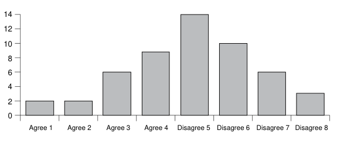

NOTE: figure/graphic rendered as an image from the PDF; its content is not machine-readable text. Caption (if any) follows as the next block.

**text found inside the figure**

14

10

8

6

4

2

0

Agree 1 Agree 2 Agree 3 Agree 4 Disagree 5 Disagree 6 Disagree 7 Disagree 8

12

**Figure 1.** DTU is able to plan efficiently for the future

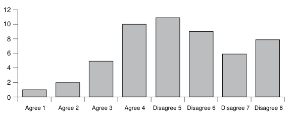

NOTE: figure/graphic rendered as an image from the PDF; its content is not machine-readable text. Caption (if any) follows as the next block.

**text found inside the figure**

12

10

8

6

4

2

0

Agree 1 Agree 2 Agree 3 Agree 4 Disagree 5 Disagree 6 Disagree 7 Disagree 8

Page 11

Journal of Management Development 17,6

#### **412**

respondents felt DTU did not treat its laid off employees in a fair manner (Figure 6).

Leader behaviors are critical in an organization change program. It was found that communicating openly (sharing intentions, listening) and collaborating (making decisions in teams) were most related to success in organization development efforts. The survey results showed that DTU

**Figure 4.** DTU manages downsizing very well

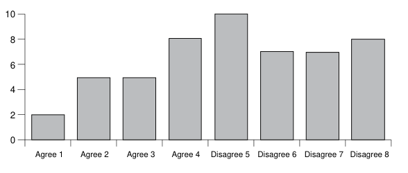

NOTE: figure/graphic rendered as an image from the PDF; its content is not machine-readable text. Caption (if any) follows as the next block.

**text found inside the figure**

10

8

6

4

2

0

Agree 1 Agree 2 Agree 3 Agree 4 Disagree 5 Disagree 6 Disagree 7 Disagree 8

**Figure 3.** DTU will perform very well two years from now

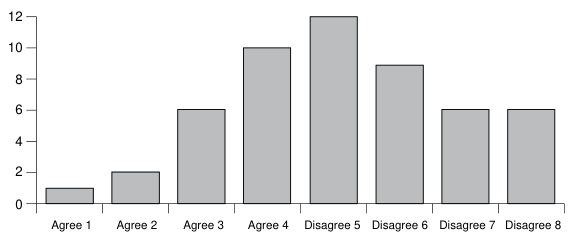

NOTE: figure/graphic rendered as an image from the PDF; its content is not machine-readable text. Caption (if any) follows as the next block.

**text found inside the figure**

12

10

8

6

4

2

0

Agree 1 Agree 2 Agree 3 Agree 4 Disagree 5 Disagree 6 Disagree 7 Disagree 8

**Figure 5.** DTU lays off the right employees

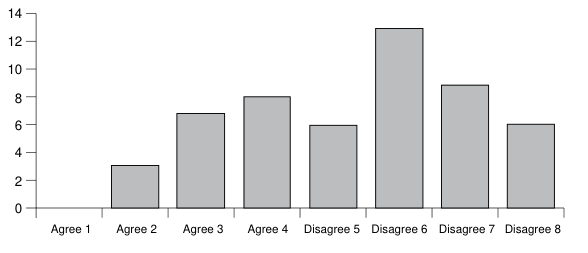

NOTE: figure/graphic rendered as an image from the PDF; its content is not machine-readable text. Caption (if any) follows as the next block.

**text found inside the figure**

14

10

8

6

4

2

0

Agree 1 Agree 2 Agree 3 Agree 4 Disagree 5 Disagree 6 Disagree 7 Disagree 8

12

Page 12

#### The aftermath

#### of downsizing

#### **413**

leadership never clarified why the downsizing occurred and did not regularly advise those affected of the new goals and objectives.

Failure to offer accurate information to employees promotes negative rumors in the organization as indicated in the survey comments. Employees will be very resentful of learning of changes from outsiders. Also, top management needs to demonstrate visible and consistent support for change. For example, if the change effort calls for team-building, then top management should be the first group to try to build teams. Management needs to show how the change will improve “outcome measures” such as profits, production, or quality of work life.

Management’s leadership in the change effort seems to be the key determinant of whether that change will succeed. It is not enough to say that leadership is critical. What is different is the type of leadership being recommended; a leadership that does more than just create and articulate a new vision for the organization; leadership that is open and collaborative. Part of communication and collaboration involves linking the intended changes to organizational outcomes such as productivity and quality of work life. The DTU survey indicates that management is not sensitive enough to the concerns of its employees (Figure 7).

Recent literature on organizational change indicates managing and changing organizations depends heavily on the “positive” use of power. Power plays are usually subtle and hidden. A key tactic is to create systems of meaning that others will accept. It is most interesting to note that slightly more than half of the respondents felt DTU was a challenging place to work (Figure 9). It appears

**Figure 6.** DTU treats its laid off

employees in a fair

manner

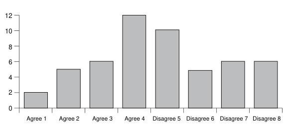

NOTE: figure/graphic rendered as an image from the PDF; its content is not machine-readable text. Caption (if any) follows as the next block.

**text found inside the figure**

12

10

8

6

4

2

0

Agree 1 Agree 2 Agree 3 Agree 4 Disagree 5 Disagree 6 Disagree 7 Disagree 8

Page 13

Journal of Management Development 17,6

#### **414**

**Figure 7.** DTU is sensitive to the concerns of its employees

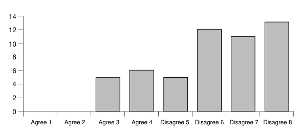

NOTE: figure/graphic rendered as an image from the PDF; its content is not machine-readable text. Caption (if any) follows as the next block.

**text found inside the figure**

14

10

8

6

4

2

0

Agree 1 Agree 2 Agree 3 Agree 4 Disagree 5 Disagree 6 Disagree 7 Disagree 8

12

**Figure 8.** DTU made the right decision when it decided to reduce its workforce

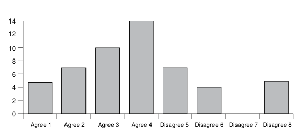

NOTE: figure/graphic rendered as an image from the PDF; its content is not machine-readable text. Caption (if any) follows as the next block.

**text found inside the figure**

14

10

8

6

4

2

0

Agree 1 Agree 2 Agree 3 Agree 4 Disagree 5 Disagree 6 Disagree 7 Disagree 8

12

**Figure 9.** DTU is a challenging place to work

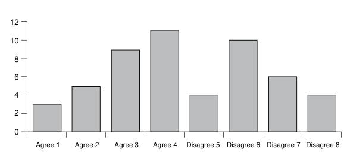

NOTE: figure/graphic rendered as an image from the PDF; its content is not machine-readable text. Caption (if any) follows as the next block.

**text found inside the figure**

12

10

8

6

4

2

0

Agree 1 Agree 2 Agree 3 Agree 4 Disagree 5 Disagree 6 Disagree 7 Disagree 8

Page 14

#### The aftermath

#### of downsizing

#### **415**

that the use of power via leadership was somewhat successful but not to the degree management wished it to be.

Organizational politics means acquiring, developing and using power to achieve one’s objectives. At the individual level, management needs to identify people who hold powerful positions and have developed a reputation of being powerful. It is also important to look at interest groups that control key resources. Powerful networks can be identified by studying key linkages between individuals and coalitions. Decades of research on individual and group behavior show that we socialize with those who are similar to us, support us, and share our goals (Clement, 1994, p. 37).

Not only must the advocate of change be aware of politics and power plays, they must also use power and politics themselves. One major problem is that much of DTU’s top management has not been able to succeed in the transition that requires “soft skills”. Fundamental change of management style is difficult in practice. To make implementation easier, management needs to understand and communicate cultural changes. Management and employees need to learn and adapt to the new system. Analysis of the situation demonstrates that many employees show resistance to change. This resistance has escalated motivation and communication problems.

Leadership is an interactive relationship between leader and follower. This relationship is based on trust, and trust is generated by a person’s sense of integrity. To be a good leader, integrity is very important and it must be combined with competence, vision, and enthusiasm. Without personal integrity, there can be no mutual trust. DTU needs to train managers to be effective in communicating, collaborating and demonstrating support for successful changes while demonstrating trustworthiness.

**Communications systems** *Survey results* Communication is a social process that includes both perception and influence. The accurate conveyance and reception of a message, plus the impact the message has on the receiver, are equally important in explaining the phenomenon of communication (Vecchio and Appelbaum, 1995, p. 562). If the organizational climate is one of openness and trust, then incomplete or controversial communications are more likely to be interpreted favorably. But when distrust is the norm, messages may be harshly scrutinized for “hidden meanings”, and even good news may be greeted with suspicion and ridicule (Vecchio and Appelbaum, 1995, p. 580).

Poor communication creates a misunderstanding of goals and strategic mission as well as misconceptions about team relationships and individual responsibilities (Vecchio and Appelbaum, 1995, p. 570). It spurs anxiety and conflict, a sense of disenfranchisement, poor productivity and increased cost to the company (Vecchio and Appelbaum, 1995, p. 570). Employees cannot support the changes the organization is making if they do not know what is going on. In a survey of 30 companies, 46 per cent of the respondents said that

Page 15

Journal of Management Development 17,6

#### **416**

“communication” contributed most to good employee morale during their transition. Conversely, the poll indicated 50 per cent said “uncertainty and the unknown” had the most negative impact on morale (Koonce, 1991, p. 23). In the DTU survey 90 per cent of respondents said morale is down compared to two years ago, prior to the company’s downsizing initiative. In addition, some of the employees commented that during the downsizing, DTU never made it clear why downsizing was happening and what the future would hold for them.

In another study by Cameron, (1994, p. 202) he states “increased communication and participation of employees in the downsizing process in determining changes in their work, were associated with increased effort and, by implication, improvement in organizational performance”.

From the results of this current survey it was found that 79 per cent of respondents think DTU puts too little emphasis on using employee ideas (Figure 11). Discussions with employees revealed that they were not involved in planning the downsizing further illuminating the lack of use of inputs and ideas. Furthermore, while informal networks serve useful functions by cutting red tape and leading to greater loyalty through positive social relations, they also may give birth to grapevines. Because they are flexible and personal, grapevines may be one of the most rapid communication systems that exist in most organizations (Vecchio and Appelbaum, 1995, p. 581). The accuracy of grapevines is quite high for non-controversial information, but with controversial information the grapevine can be greatly in error. One of the varieties of information passing through grapevines are rumors. Rumors are unverified beliefs that are transmitted from one person to another. Because

**Figure 10.** Improving employeremployee relations

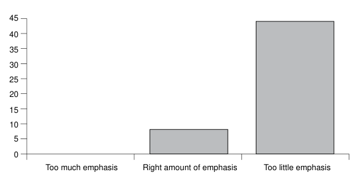

NOTE: figure/graphic rendered as an image from the PDF; its content is not machine-readable text. Caption (if any) follows as the next block.

**text found inside the figure**

45

5

0

Too much emphasis

40

35

30

25

20

15

10

Right amount of emphasis Too little emphasis

Page 16

#### The aftermath

#### of downsizing

#### **417**

rumors can harm both individuals and the organization itself, managers must consider how to control and eliminate the rumor mill (Vecchio and Appelbaum, 1995, p. 581). A study in 1991 highlighted the importance of communication and collaboration in an effort of change in 43 organizations. The most commonly cited reason for failure of the change effort was the presence of inaccurate and negative rumors, often caused by management neglecting to provide timely and accurate information (Clement, 1994, p. 36). Many of those surveyed indicated with comments that too many rumors were left unresolved for too long before, during and after the downsizing.

In the study carried out by Cameron (1994, p. 201), he concluded that “the firms that improved their performance were those that prepared for downsizing in advance” and that “gradual reductions were consistently associated with performance increases”. Performance increases will only be achieved if the survivors are properly prepared and motivated. This obviously was not done at DTU and to gain the employees loyalty, trust and commitment to the new organization they must develop a communication plan to demonstrate the place of the variables and impact on those affected and the survivors.

DTU’s management must move from being a parent to employees and become a facilitator, coach and resource. In this context, communication becomes much more than the transmission of information; it is the sharing of power, a recognition that people are the most important resource (Vecchio and Appelbaum, 1995, p. 570). Techniques for improving communication in organizations include: using appropriate language, practicing empathic communication, encouraging feedback, developing a climate of trust, using appropriate media, encouraging effective listening, and ensuring that efforts are in unison with the overall corporate strategy (Vecchio and Appelbaum, 1995, p. 585).

**Figure 11.** Making more and better

use of ideas from

employees

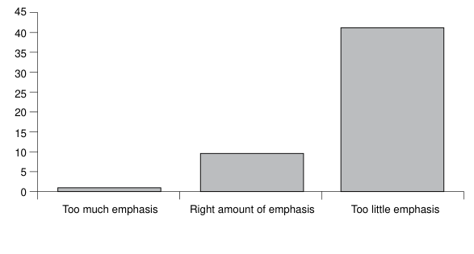

NOTE: figure/graphic rendered as an image from the PDF; its content is not machine-readable text. Caption (if any) follows as the next block.

**text found inside the figure**

45

5

0

Too much emphasis

40

35

30

25

20

15

10

Right amount of emphasis Too little emphasis

Page 17

Journal of Management Development 17,6

#### **418**

**Decision-making dynamics at Dominion Travelogics Unlimited** *Some models* Stewart in “Culture and decision-making” refers to decision-making as an “overt process that is the bridge between mind and action” (Gudyhurst *et al.*, 1985). Introducing an improved decision-making process can help rebuild group cohesion and provide management and employees with an inventory of problems with mutually agreed on priorities. To do this, it was decided that NGT be utilized.

The “nominal group technique” (NGT) is a decision-making method that combines structure and important opportunities for social interaction while being a task-oriented procedure. The basic steps of the technique are outlined in Table I.

Some key advantages of NGT are: • benefit of small group social interaction to establish rapport, build cohesion, and offer improved decision-making quality (suggested group size ranges from seven to ten people); • relatively short timeframe to expect results and limited cost (as compared with a Delphi technique or exhaustive surveys). DTU management can anticipate a reasonably quick response to immediate problems while identifying others as longer term; • provides for the recognition and sensitivity and use of ideas that DTU staff indicated were most desirable factors for their positions (see Appendix). A complementary technique to NGT is “bootstrapping” or the “expert systems” technique (see Table I). Bootstrapping analyzes the actual decision-making

Nominal group technique

(1) Private record of ideas (2) Presentation of ideas (3) All ideas are clarified and evaluated (4) Silent vote on the best idea(s)

*Caution:* Beware of groupthink

Escalation of commitment Risk-taking (risky shift)

Bootstrapping (a.k.a. expert systems)

(1) Record the decision process (2) Flow chart the results (3) Revise the system where required

**Note:** Research shows high quality decision can result

**Source:** Vecchio and Appelbaum, pp. 422-5

**Table I.** Decision-making dynamics: some models

Page 18

#### The aftermath

#### of downsizing

#### **419**

process, focusing more on the steps that make up the decision process. There is more flexibility in bootstrapping than in NGT since almost any number of people at any level of the organization can meet and employ the method. Also, group composition can more easily be changed to address a particularly urgent concern.

Like NGT, bootstrapping offers more opportunity for social interaction and will underscore the organizational commitment to the development of a new organizational culture that requires less dependence by employees on subculture networks for what should be routine company communication. In the new culture, employees routinely share in the decision-making.

The combination of NGT and bootstrapping can help DTU recover more quickly from the effects of downsizing. The emphasis is on improved socialization within the organization; improved communication, and better quality decision-making. The expected results would be better overall satisfaction levels, increased performance ratings, and more complementary formal and informal cultures if the techniques are properly supported and employed. A suggested action plan is:

• the principles of NGT and bootstrapping decision-making techniques should be presented to the chief executive officer and senior staff for acceptance and solicitation of commitment. A trial of the two techniques (seminar session or actual work situation) can be made at the top management level to provide evidence of the effectiveness of these two decision-making processes; • communicate the techniques to other work groups receptive to decisionmaking performance improvement; • act on the inventories of problems identified and the ideas generated. A summary of the decision-making process for DTU is presented in Table II. Complementing the increased participation of employees that the selected decision-making techniques require, is the current thought on incentive programs and team building which is the focus of the next section of the DTU case study.

**Incentives and satisfaction** *Survey results* The survey indicated that one-half of the respondents were dissatisfied with the job security situation in light of the recent downsizing exercises. Further, while the workload was not a significant concern, 75 per cent indicated dissatisfaction with salary relative to workload (Figure 12).

A total of 70 per cent of respondents stated they are dissatisfied with the level of recognition they receive form DTU. The employees also commented that the travel benefits were a significant incentive that was lost without compensation in the downsizing process. The company must find a way to signify the importance of its human resources as an asset. The primary key to

Page 19

Journal of Management Development 17,6

#### **420**

A. Nominal group technique (NGT) B. Bootstrapping

*Existing work group New work group* • strong subculture “survivors” • improved decision-making skills • fearful (job security issue) • cohesion • low morale • recognition • low cohesions • increased effectiveness *Goals:* Inventory current problems Prioritize current problems *Benefits:* Research shows<sup>a</sup> More interaction = more common

subjective (informal) culture *Confidence building:* Stress relief Shows initiative *Action focus:* • doing something – not “stewing” • promotes tasks, reduces “noise” • avoids problems of more expensive longer procedures • minimal consulting cost if any • results within a normal operating quarter or less *Caution:* Management commitment required

Implementation is a process distinct from these techniques

**Note:** <sup>a</sup> Gudyhurst *et al.* (1985)

**Table II.** Decision-making: a summary

**Figure 12.** Satisfaction levels: job security, salary, workload

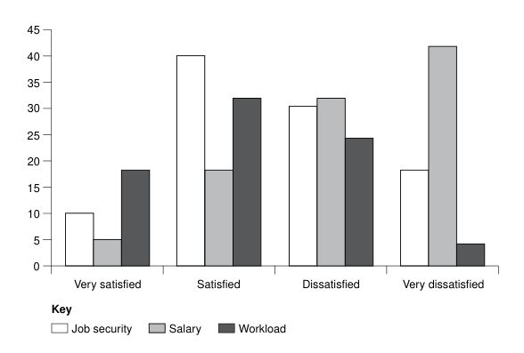

NOTE: figure/graphic rendered as an image from the PDF; its content is not machine-readable text. Caption (if any) follows as the next block.

**text found inside the figure**

45

5

0

Very satisfied

40

35

30

25

20

15

10

Satisfied Dissatisfied Very dissatisfied

Job security Salary Workload

**Key**

Page 20

#### The aftermath

#### of downsizing

#### **421**

competitive advantage today is the effective use of people. Employees must become stakeholders in the success of the organization. Two thirds of the respondents reported dissatisfaction with the recognition they received irrespective of the pay for a job well done (Figure 13).

An efficient incentive program will send clear messages about the organization values, and will help reinforce human resources and business strategy. DTU must empower its team effectively. A team can be defined as a “group of people with complementary skills who are committed to a common purpose, performance goals and approach for which they hold themselves mutually accountable” (Horowitz, 1993, p. 3). Empowerment is described in the same article as “a condition that occurs when employees know, understand and are committed to customer-oriented objectives; have a feedback system to determine whether actions are working as intended; and have accountability for the outcomes (Horowitz, 1993, p. 2).

The survey also revealed that more than half of the respondents were dissatisfied with opportunities for upgrading skills and knowledge which would impact on incentives and satisfaction and more than 50 per cent reported that DTU did not make use of their ideas to improve work. However, more than half were satisfied with the support they received from their superiors during downsizing (Figure 14).

Under this climate, DTU leadership would have the responsibility for creating an environment conducive to team empowerment. Managers at all levels must demonstrate commitment and behavioral models. They must be

**Figure 13.** Satisfaction levels: skills

use, feedback,

recognition

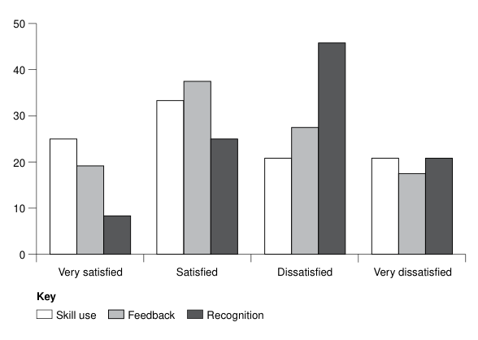

NOTE: figure/graphic rendered as an image from the PDF; its content is not machine-readable text. Caption (if any) follows as the next block.

**text found inside the figure**

0

Very satisfied

40

30

20

10

Satisfied Dissatisfied Very dissatisfied

Skill use Feedback Recognition

**Key**

50

Page 21

Journal of Management Development 17,6

#### **422**

willing to change their behaviors to support teams and be able to maintain those behaviors during difficult times. Employees need to be willing to work in teams and assume additional responsibilities. The advantage of team-building efforts is that once any changes are accepted by the group, group members themselves can reinforce the new patterns of behavior.

When employees ranked work in general, they reported job security to be a prime consideration more significant than salary, benefits or flexible schedules. They also ranked fair treatment on the job to be more important to them than challenging work, support from superiors/co-workers, or clear objectives. What was interesting was that 60 per cent were satisfied with DTU in terms of basic financial needs being satisfied. However, there are some interesting results and data to place this satisfaction ranking into a more lucid frame of reference.

**Figure 14.** Satisfaction levels: upgrades, ideas use, support

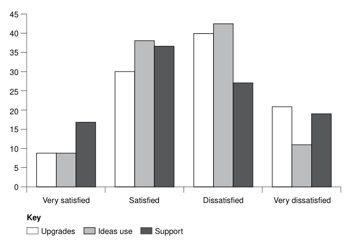

NOTE: figure/graphic rendered as an image from the PDF; its content is not machine-readable text. Caption (if any) follows as the next block.

**text found inside the figure**

45

5

0

Very satisfied

40

35

30

25

20

15

10

Satisfied Dissatisfied Very dissatisfied

Upgrades Ideas use Support

**Key**

Page 22

#### The aftermath

#### of downsizing

#### **423**

It was at this juncture that DTU management decided to introduce gainsharing as an incentive intervention to compensate for the downsized climate.

**Gainsharing: a prescription or a bandaid?** A high level of empowerment can be obtained by gainsharing. It can be described as a process that combines participatory management and profit sharing. According to Markowitch, “it give employees selfish reason to care and increase productivity by linking their bottom line (pay check) with the company’s bottom line” (Markowitch, 1994, p. 70). Gainsharing attempts to have employees think and act like business owners.

There are three types of gainsharing: profitability gate; variable share; and financially funded family of measures. The profitability gate is the simplest and best known mechanism. It requires that a certain level of profitability be achieved in order for a gainsharing payout to be made. The required level is

**Figure 16.** Now considering DTU

as an employer, on the whole, how good or bad is DTU as a company to

work for?

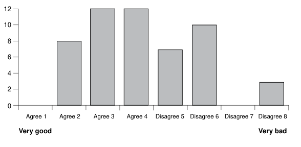

NOTE: figure/graphic rendered as an image from the PDF; its content is not machine-readable text. Caption (if any) follows as the next block.

**text found inside the figure**

12

10

8

6

4

2

0

Agree 1 Agree 2 Agree 3 Agree 4 Disagree 5 Disagree 6 Disagree 7 Disagree 8

**Very good Very bad**

**Figure 15.** Compared to two years ago, has morale among

employees you work

with gone…?

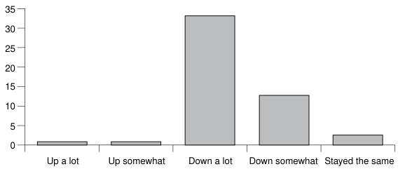

NOTE: figure/graphic rendered as an image from the PDF; its content is not machine-readable text. Caption (if any) follows as the next block.

**text found inside the figure**

5

0

Up a lot

35

30

25

20

15

10

Up somewhat Down a lot Stayed the same Down somewhat

Page 23

Journal of Management Development 17,6

#### **424**

usually derived from a budget. However, this plan can have a negative effect if profitability is not reached. The variable share system has a lower risk. This system ties the employee share of the gainsharing to a level of profitability. The more profitable DTU, the better the bonus for the employees.

The financially funded family of measures relates bonus payments to performance on the job. In this approach, the pool of money that is available to employees is contingent with other goals that are meaningful to employees and management, like safety, attendance, and productivity. Management decided on the following for the DTU situation.

The recommended system for DTU would be the variable share system based on the following guideline:

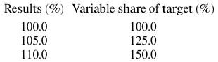

NOTE: complex table shown as an image of the PDF; the text below is a rough machine extraction and may be mis-aligned.

**extracted text (unreliable layout)**

[output not shown]

NOTE: table converted from PDF layout to HTML text; cell boundaries are reconstructed. See PDF if exact alignment matters.

**Downsizing: conclusions and recommendations** The framework is based on the premise that there are no winners and that planning a downsizing is actually a painful process of determining where

**Figure 17.** How would you describe yourself compared to how you were feeling two years ago? 0

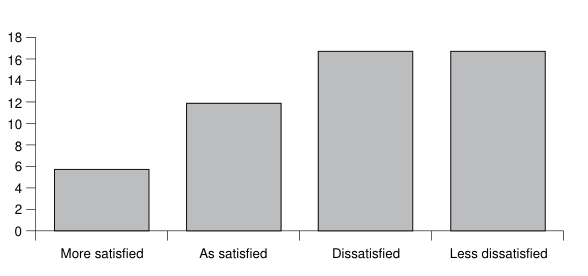

NOTE: figure/graphic rendered as an image from the PDF; its content is not machine-readable text. Caption (if any) follows as the next block.

**text found inside the figure**

More satisfied As satisfied Dissatisfied Less dissatisfied

18

16

14

12

10

8 6

4

2

Page 24

#### The aftermath

#### of downsizing

#### **425**

trade-offs can be made so that no stakeholder is disadvantaged more than is necessary.

Based on the above findings and analysis of actual practices, a final proposed process model (Figure 18) is recommended for use by organizations as a guide when planning to downsize. This final model includes two major changes: improving the survivor support plan by setting it up as a sub-process in the model, and including an additional sub-model that includes elements that relate to operational practices after downsizing both in HRM practices and in work processes.

As was pointed out by Koonce (1991) and Isabella (1989), addressing survivor needs is essential to the new organization if its strategic objectives are to be achieved. This therefore necessitates a stronger emphasis on survivor needs, since this seems to be the major weakness in all organizations studied. A structured process is therefore recommended for the survivor support plan as well. This may be done through:

(1) setting objectives for the survivor support plan; (2) determining additional costs for the plan; (3) developing the plan; (4) implementing the plan; (5) evaluating the plan after implementation is complete; and (6) amending the plan, if and when necessary. (Labib and Appelbaum, 1993,

p. 87; 1994, p. 81.) Addressing survivor needs, by itself, however, does not ensure the successful attainment of corporate objectives after downsizing. Survivors must also be supported by the new organization operationally. This, therefore, is not just an HRM issue, but a strategic and operational management issue as well. Organizations can address these issues through several activities that can be initiated before, during, and after downsizing that pertain to the restructuring of HRM practices and organizational operating processes. Examples of these are a:

• comprehensive, continuous, and honest communication program; • restructuring of job designs and the supporting compensation packages; • comprehensive employee development program that reinforces the new career paths, the new performance standards, the organization’s commitment to its human resources, and the organization’s emphasis on security in personal development rather than job security within the organization; • radical change in the day-to-day operating standards and procedures to reflect the changes in the organizational structure and the job restructuring. This should be accompanied by corresponding changes in the performance evaluation systems of the organization.

Page 25

Journal of Management Development 17,6

#### **426**

**Figure 18.** Final proposed process model for developing and implementing downsizing plans

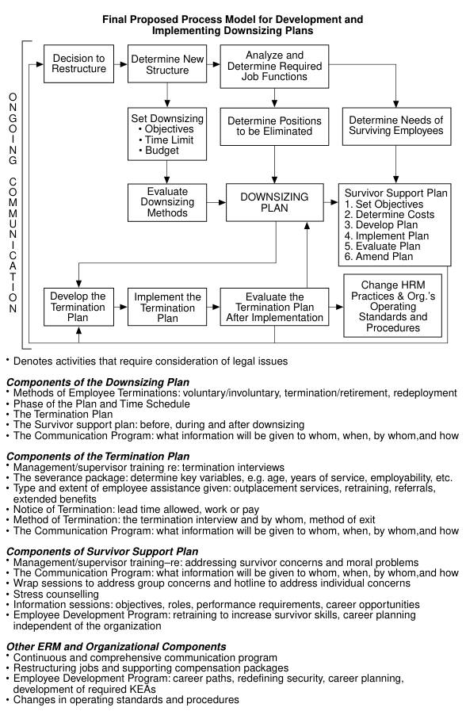

NOTE: figure/graphic rendered as an image from the PDF; its content is not machine-readable text. Caption (if any) follows as the next block.

**text found inside the figure**

**Final Proposed Process Model for Development and**

**Implementing Downsizing Plans**

Decision to Restructure

Determine New

Structure

Analyze and Determine Required

Job Functions

Set Downsizing

• Objectives • Time Limit

• Budget

Determine Positions

to be Eliminated

Determine Needs of Surviving Employees

DOWNSIZING

PLAN

Evaluate Downsizing

Methods

Survivor Support Plan 1. Set Objectives 2. Determine Costs 3. Develop Plan 4. Implement Plan 5. Evaluate Plan 6. Amend Plan

Develop the Termination

Plan

Change HRM Practices & Org.’s

Operating Standards and

Procedures

Implement the

Termination

Plan

Evaluate the Termination Plan After Implementation

O N G O

I N G

C O M M U N

I C A T

I O N

• Denotes activities that require consideration of legal issues

**Components of the Downsizing Plan** • Methods of Employee Terminations: voluntary/involuntary, termination/retirement, redeployment • Phase of the Plan and Time Schedule • The Termination Plan • The Survivor support plan: before, during and after downsizing • The Communication Program: what information will be given to whom, when, by whom,and how

**Components of the Termination Plan** • Management/supervisor training re: termination interviews • The severance package: determine key variables, e.g. age, years of service, employability, etc. • Type and extent of employee assistance given: outplacement services, retraining, referrals, extended benefits • Notice of Termination: lead time allowed, work or pay • Method of Termination: the termination interview and by whom, method of exit • The Communication Program: what information will be given to whom, when, by whom,and how

**Components of Survivor Support Plan** • Management/supervisor training–re: addressing survivor concerns and moral problems • The Communication Program: what information will be given to whom, when, by whom,and how • Wrap sessions to address group concerns and hotline to address individual concerns • Stress counselling • Information sessions: objectives, roles, performance requirements, career opportunities • Employee Development Program: retraining to increase survivor skills, career planning independent of the organization

**Other ERM and Organizational Components** • Continuous and comprehensive communication program • Restructuring jobs and supporting compensation packages • Employee Development Program: career paths, redefining security, career planning, development of required KEAs • Changes in operating standards and procedures

Page 26

#### The aftermath

#### of downsizing

#### **427**

An important element in the employee development plan is a strong emphasis on the employees’ need to manage their own careers independent of the opportunities available within the organization (Labib and Appelbaum, 1993, p. 89; 1994).

To address survivor needs, the communication plan does not have to be formal and support does not necessarily have to include expensive counselling. Frequent dialogue with key members of management may be all that is needed. Also, retaining the services of an industrial psychologist may prove less costly than contracting an outplacement firm, if the number of employees involved is not very high. Other types of counselling, such as financial advice and jobsearch techniques can be provided by the organization’s own finance department and HR recruitment and selection staff may advise employees about job search techniques if they are trained to do so. In fact, for organizations that are in a continuous downsizing mode, providing some outplacement services such as financial counselling and job search training in-house may be a less costly alternative to using outside sources.

It is important for organizations to realize that although the proposed model involves incurring costs that are not directly related to the actual downsizing, they cannot afford not to address survivor needs in a more comprehensive and operational way. To do so, HRM policies must be changed to emphasize the new orientation and changed vision of the organization and work processes must be adjusted to the smaller size and different objectives of the new organization. In the long-run, the price an organization pays for not adequately addressing these issues may either be its “death”, or growing “fat” again and having to experience the pains of major downsizing all over again (Labib and Appelbaum, 1993, p. 90).

**Comprehensive conclusions and recommendations** It was observed from the survey results that DTU’s corporate culture is not in harmony with its employee culture. The major factors affecting the cultural problem were found to be leadership, communication, decision making and motivation.

*Proposed organizational change* In order for DTU to regain commitment from its employees, it is recommended that the following be considered: *Culture*

• change must originate from top management and communicate the reason behind the change to employees; • cultural changes should be communicated where possible; • take steps to understand employee culture (questionnaires, focus groups); • involve employees in the change process, ask for opinions and ideas;

Page 27

Journal of Management Development 17,6

#### **428**

• create common organizational experiences; • align company needs with employees’ needs. *Leadership*

• develop open and collaborative leadership; • top management needs to develop “soft skills”; • identify the key leaders in the informal groups. *Communication*

• develop a climate of trust; • help managers deal with inaccurate and negative rumors (training); • help managers to improve their communication techniques (training). *Decision making*

• begin NGT and bootstrapping program; • act on inventory of problems and ideas immediately with affected employees (the survivors). *Group incentive*

• concentrate efforts on team building; • propose an incentive program that would motivate employees (gainsharing). *Downsizing*

• develop downsizing plan; • develop survivor support plan; • develop termination plan. It is recommended that management clarify the employees’ role in the organization’s new culture (Appelbaum *et al.,* 1987). Direct improvements to productivity and job satisfaction would arise from goal setting accompanied with feedback, and training sessions for employees which would build a dynamic team. With these dual approaches, one can ensure that employees have clear direction and have the proper training to achieve goals.

#### **Action plan[1]**

• President to make direct inspirational, speech to employees disclosing reasons for downsizing and criteria used to decide who was terminated. In addition, outline company mission, vision and objectives (within two weeks). • Involve employees in identifying what needs to change since downsizing (within two weeks). • Begin using decision-making techniques, introduce the prescribed techniques on a small scale and as an experiment to be less threatening.

Page 28

#### The aftermath

#### of downsizing

#### **429**

Feedback of the decision-making techniques to get a reply from management (within three weeks). • Train supervisors on how to motivate and manage survivors (within three months). • Communicate incentive program, receive feedback and initiate final version of the group incentive program (within three months). • Involve survivors of downsizing in next steps for DTU to maximize its potential and on career management (immediately – tomorrow).

#### **Note**

1. Interviews/consultation with Ron Stewart, George Gault, Denis Faubert, Michel Deslauriers (participants EMBA Program, Concordia University, Montreal, Quebec), September 1996.

**References** Appelbaum, S.H. (1976), “The organizational climate study: an intervention strategy to change a

department”, *University of Michigan Business Review*, Vol. 28 No. 5, September, pp. 12-16. Appelbaum, S.H. (1984), “The organizational climate audit … or how healthy is your hospital?”,

*American College of Hospital Administrators Journal*, Vol. 29 No. 1, January/February, pp. 51-70. Appelbaum, S.H., Simpson, R. and Shapiro, B.T. (1987), “The tough test of downsizing”,

*Organizational Dynamics*, Vol. 16 No. 2, Autumn, pp. 68-79. Cameron, K.S. (1994), “Strategies for successful organizational downsizing”, *Human Resource*

*Management,* Summer. Carr, C. (1994), “Seven keys to successful change”, *Training*, February, pp. 55-60. Clement, R.W. (1994). “Culture, leadership, and power: the keys to organizational change”,

*Business Horizons,* January February, pp. 33-8. Gudyhurst, W.B., Stewart, L.P. and Ting-Toomey, S. (Eds) (1985), *Communication, Culture, and*

*Organizational Process,* Sage Publication, Beverly Hills, CA. Horowitz, D. (1993), “Empowering teams effectively”, *American Compensation Association News,*

August, pp. 2-3. Isabella, L.A. (1989), “Downsizing: survivors assessment”, *Business Horizons*, May-June,

pp. 35-61. Koonce, R. (1991), “The people side of organizational change”, *Credit Magazine,* Vol. 17 No. 6,

November/December, pp. 22-5. Labib, N. and Appelbaum, S.H. (1993), “Strategic downsizing: a human resources perspective”,

*Human Resource Planning,* Vol. 16 No. 4, pp. 69-93. Labib, N. and Appelbaum, S.H. (1994), “The impact of downsizing practices on corporate

success”, *The Journal of Management Development*, Vol. 13 No. 7, pp. 59-84. Litwin, G. and Taguiri, R. (1968), “Organizational climate: explorations of a concept”, *Boston*

*Division of Research,* Graduate School of Business, Harvard University, Cambridge, MA. Markowitch, M. (1994), “Does money motivate?”, *Compensation and Benefit Review*, January,

p. 70. Schein, E. (1985), *Organizational Culture and Leadership,* Jossey-Bass Publishers, San Francisco,

CA, p. 358. Vecchio, R.P. and Appelbaum, S.H. (1995), *Managing Organizational Behaviour: A Canadian*

*Perspective*, Dryden-Harcourt, Brace & Co., Toronto, Ontario. Woodward, H. and Buchholz, S. (1987), *Aftershock, Helping People Through Corporate Change,*

John Wiley & Sons, New York, NY.

Page 29

Journal of Management Development 17,6

#### **430**

**Appendix** *Attitude survey* A. Please indicate your level of agreement with the following statements on an 8-point scale “1”

being that you strongly agree and “8” means that you strongly disagree.

|  |  | Strongly |  |  |  |  |  | Strongly |
| --- | --- | --- | --- | --- | --- | --- | --- | --- |
|  |  | agree 1 | 2 | 3 | 4 | 5 | 6 | disagree 7 8 |
| (1) | DTUisabletoplanefficientlyforthe | (1) | (2) | (5) | (10) | (11) | (9) | (6) (8) |
|  | future |  |  |  |  |  |  |  |
| (2) | DTUhascleargoalsandobjectives | (2) | (2) | (6) | (9) | (14) | (10) | (6) (3) |
|  | forthefuture |  |  |  |  |  |  |  |
| (3) | DTUwillperformverywelltwoyears | (1) | (2) | (6) | (10) | (12) | (9) | (6) (6) |
|  | fromnow |  |  |  |  |  |  |  |
| (4) | DTUmanagesdownsizingverywell | (2) | (5) | (5) | (8) | (10) | (7) | (7) (8) |
| (5) | DTUlaysofftherightemployees | (0) | (3) | (7) | (8) | (6) | (13) | (9) (6) |
| (6) | DTUtreatsitslaidoffemployeesin | (2) | (5) | (6) | (12) | (10) | (5) | (6) (6) |
|  | afairmanner |  |  |  |  |  |  |  |
| (7) | DTUissensitivetotheconcernsofits | (0) | (0) | (5) | (6) | (5) | (12) | (11) (13) |
|  | employees |  |  |  |  |  |  |  |
| (8) | DTUmadetherightdecisionwhenit | (5) | (7) | (10) | (14) | (7) | (4) | (0) (5) |
|  | decidedtoreduceitsworkforce |  |  |  |  |  |  |  |
| (9) | DTUisachallengingplacetoworkat | (3) | (5) | (9) | (11) | (4) | (10) | (6) (4) |

NOTE: table converted from PDF layout to HTML text; cell boundaries are reconstructed. See PDF if exact alignment matters.

B. Many things can contribute to increasing the earnings and profits of a company. In your

view, how much emphasis does DTU place on each of the following ways to improve its earning?

|  | Toomuch | Aboutthe | Toolittle |
| --- | --- | --- | --- |
|  | emphasis | rightamount | emphasis |
|  |  | ofemphasis |  |
| (12) Improving employer-employee relations | (0) | (8) | (44) |
| (13) Educating training and re-training employees , , | (7) | (30) | (15) |
| (14) Makingmoreandbetteruseofideasfromemployees | (1) | (10) | (41) |
| (15) WasthedownsizingprocessatDTU ? … |  |  |  |
| Totallyfair(0) |  |  |  |
| Fair(31) |  |  |  |
| Unfair(18) |  |  |  |
| Totallyunfair(3) |  |  |  |

NOTE: table converted from PDF layout to HTML text; cell boundaries are reconstructed. See PDF if exact alignment matters.

C. Thinking about different aspects of your job, how satisfied or dissatisfied are you with...

|  |  | Very | Somewhat | Somewhat Very |
| --- | --- | --- | --- | --- |
|  |  | satisfied | satisfied | dissatisfieddissatisfied |
| (16) | Yourjobsecurity? | (5) | (21) | (16) (10) |
| (17) | Yoursalaryrelativetoyourworkload? | (3) | (10) | (17) (22) |
| (18) | Yourworkload? | (10) | (26) | (13) (3) |
| (19) | Theopportunitytouseyourskillsand |  |  |  |
|  | knowledgeonthejob? | (13) | (17) | (11) (11) |

NOTE: table converted from PDF layout to HTML text; cell boundaries are reconstructed. See PDF if exact alignment matters.

Page 30

| (20) Theamountoffeedbackyoureceivefrom yoursuperiorsaboutyourwork performance? (21)Therecognitionyoureceiveoutsideof payforajobwelldone? | (10) (4) | (19) (13) | (14) (24) | (9) (11) | The aftermath of downsi zing |
| --- | --- | --- | --- | --- | --- |
| (22)Youropportunitiesforupgradingyour knowledge? | (5) | (16) | (21) | (10) |  |
| (23)Theusemadeofyourideastoimprove yourwork? | (5) | (20) | (22) | (5) | 431 |
| (24)Theamountofsupportyourreceivefrom yoursuperiors? | (9) | (19) | (14) | (10) |  |

NOTE: table converted from PDF layout to HTML text; cell boundaries are reconstructed. See PDF if exact alignment matters.

D. (25) Thinking of what is important about work in general, rank the following statements:

(“1” being the most important, “5” being the least important) — Flexible work schedule (most employees rated it #5) — Job security (most employees rated it #1) — High salary (most employees rated it #2) — Generous benefits (most employees rated it #3) — Good pension plan (most employees rated it #4)

(26) Thinking of what is important about your current job, rank the following statements:

(“1” being the most important, “5” being the least important) — Challenging work (most employees rated it #2) — Support from superiors (most employees rated it #3) — Support from co-workers (most employees rated it #5) — Clear objectives (most employees rated it #4) — Fair treatment (most employees rated it #1)

(27) All things considered, as an employee would you say you are …?

— Very satisfied (3) — Somewhat satisfied (29) — Somewhat dissatisfied (18) — Very dissatisfied (2)

(28) How would you describe yourself compared to how you were feeling two years ago? (If you

joined DTU within the last two years then respond based on your views today compared to when you joined the company). — More satisfied (6) — As satisfied (12) — Dissatisfied (17) — Less satisfied (17)

(29) Now considering DTU as an employer, on the whole, how good or bad is the company to

work for?

Very good Very bad (0) (8) (12) (12) (7) (10) (0) (3)

(30) Compared to two years ago, has morale among employees you work with gone ...?

— Up a lot (1) — Up somewhat (1) — Down a lot (34) — Down somewhat (13) — Stayed about the same (3)